# Regression-Gradient Transport On Quadric Hypersurfaces

# Purpose

This report validates the coordinate-based regression-gradient transported Hessian on data-derived graphs sampled from quadratic graph hypersurfaces. The sampled points have intrinsic coordinates

$$u=(u_1,\ldots,u_m)\in \mathbb R^m$$

and ambient data coordinates

$$\Phi(u)=\bigl(u,\ q(u)\bigr), \qquad
q(u)=\sum_{i=1}^{k} c_i u_i^2-\sum_{i=k+1}^{m} c_i u_i^2.$$

The graph is built as a connected symmetric kNN graph in the ambient data coordinates $\Phi(u)$. The operator is always fit with

```r
transport.rule = "regression.gradient"
gradient.coordinate.method = "coordinates"
```

but we compare three coordinate sources passed to the gradient regression: the intrinsic chart $u$, the ambient data matrix $\Phi(u)$, and a PCA projection of $\Phi(u)$ to the known intrinsic dimension.

The crucial point is that the probes are always intrinsic polynomials:

$$1,\quad u_i,\quad u_i u_j.$$

Thus the primary test asks whether the operator behaves like an intrinsic second-difference-like construction even when it receives ambient data coordinates.

**Build:** 2026-05-19 04:01:27 EDT  
**Mode:** smoke  
**Runs:** 24  
**Cases:** 4

# Affine Intrinsic Probes

The primary diagnostic is the mean residual over intrinsic affine probes:

$$R_{\mathrm{aff}}
=
\frac{1}{m}\sum_{i=1}^m
\frac{\|A u_i\|_2}{\|u_i\|_2}.$$

For an intrinsic Hessian-like operator this should be small. Curvature tests whether ambient data coordinates remain reliable as the surface bends away from its parameter plane.

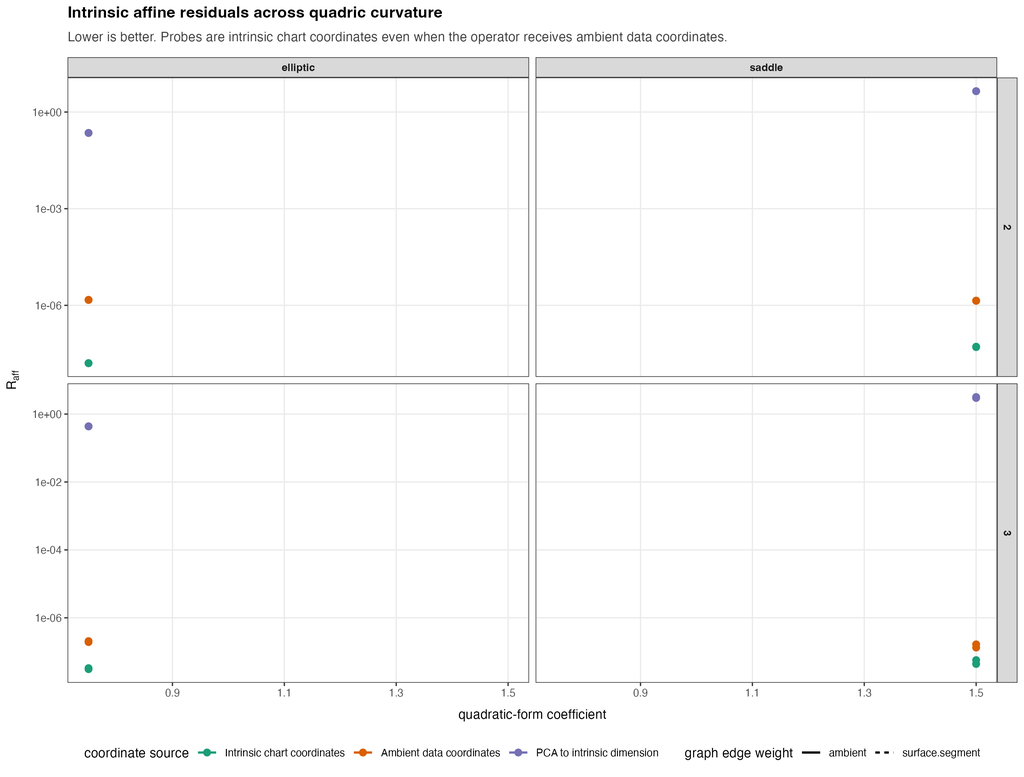

The intrinsic-coordinate curve is the oracle reference. The ambient-coordinate curve is the practical data-matrix case. A widening gap between the two as curvature increases indicates curvature bias in the local ambient-coordinate gradient regression.

# Quadratic Intrinsic Probes

For this second-difference-like operator, intrinsic quadratic probes should not be annihilated. The mean quadratic residual is

$$R_{\mathrm{quad}}
=
\frac{1}{|\mathcal Q|}
\sum_{i\le j}
\frac{\|A(u_i u_j)\|_2}{\|u_i u_j\|_2}.$$

If both affine and quadratic residuals vanish, the operator is too weak.

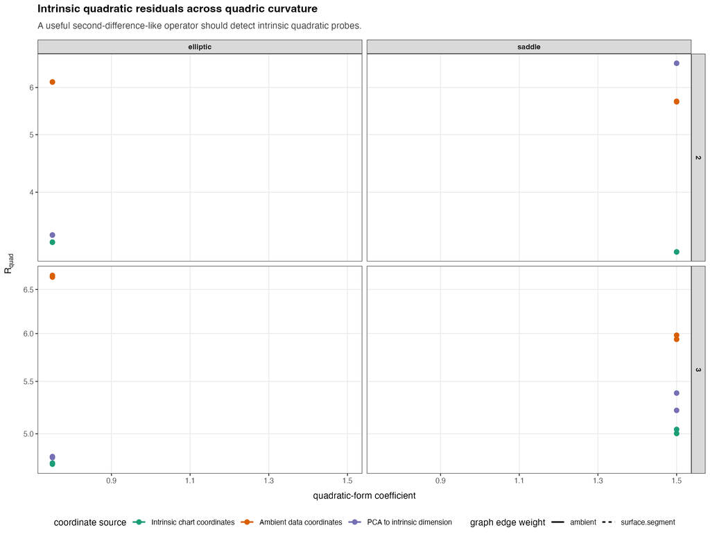

# Ambient Versus Intrinsic Gap

The ratio

$$\frac{R_{\mathrm{aff}}(\mathrm{ambient})}
{R_{\mathrm{aff}}(\mathrm{intrinsic})}$$

summarizes the penalty for using the available data coordinates instead of the unobserved intrinsic chart. Values near one mean ambient coordinates are essentially as good as the intrinsic oracle. Large values indicate curvature or sampling effects.

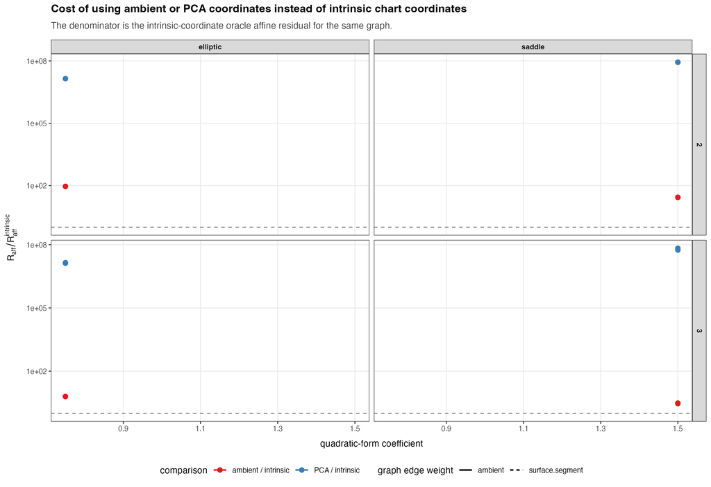

# Local Gradient Conditioning

Regression-gradient transport depends on local weighted least-squares gradient fits. The next diagnostic shows whether poor affine residuals coincide with rank deficiency or ill conditioning.

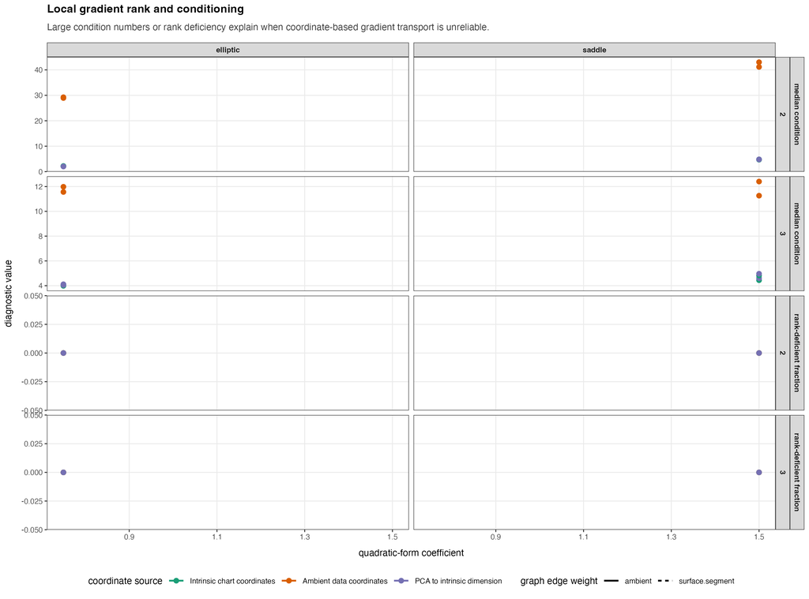

# Results Summary

Median diagnostics by intrinsic dimension, coordinate source, and graph edge weight.

| intrinsic.dim | coordinate.source | graph.weight | residual.linear.mean | residual.quadratic.mean | rank.deficient.fraction | median.local.condition |
| --- | --- | --- | --- | --- | --- | --- |
| 2 | ambient | ambient | 0.0000 | 5.9087 | 0 | 35.0434 |
| 3 | ambient | ambient | 0.0000 | 6.3251 | 0 | 11.4135 |
| 2 | intrinsic | ambient | 0.0000 | 3.2354 | 0 | 3.4389 |
| 3 | intrinsic | ambient | 0.0000 | 4.8902 | 0 | 4.2545 |
| 2 | pca_intrinsic_dim | ambient | 2.3312 | 4.9906 | 0 | 3.4387 |
| 3 | pca_intrinsic_dim | ambient | 1.7064 | 5.0073 | 0 | 4.3638 |
| 2 | ambient | surface.segment | 0.0000 | 5.9053 | 0 | 36.1332 |
| 3 | ambient | surface.segment | 0.0000 | 6.2926 | 0 | 12.1939 |
| 2 | intrinsic | surface.segment | 0.0000 | 3.2360 | 0 | 3.4746 |
| 3 | intrinsic | surface.segment | 0.0000 | 4.8669 | 0 | 4.4031 |
| 2 | pca_intrinsic_dim | surface.segment | 2.3395 | 4.9911 | 0 | 3.4048 |
| 3 | pca_intrinsic_dim | surface.segment | 1.8068 | 5.0865 | 0 | 4.5101 |

## What We Learned

The validation used 24 successful runs over 4 quadric cases. The intrinsic-chart coordinate source is the oracle reference, while ambient coordinates are the practical data-derived graph setting.

The median intrinsic affine residual was 7.93e-07 for ambient coordinates, 3.83e-08 for intrinsic coordinates, and 1.71 for PCA coordinates. These numbers should be read against the quadratic residuals, whose medians were 6.05, 4.01, and 5.01 respectively.

The desired pattern is low affine residual together with nonzero quadratic residual. The intrinsic-coordinate oracle tells us whether the operator itself behaves correctly on the graph, while the ambient and PCA curves measure the price of using data coordinates on a curved embedding.

The main practical interpretation is that supplied-coordinate regression-gradient is a valid target for data-derived graphs, but curvature strength and local conditioning determine how close ambient coordinates come to the intrinsic-chart oracle.

# Appendix

## Summary Table

| case.id | intrinsic.dim | surface | curvature | n | seed | k | index.k | graph.weight | coordinate.source | coordinate.label | coordinate.dim | status | runtime.sec | n.edges | n.mst.edges.added | n.rows | nullity.estimate | median.local.rank | min.local.rank | rank.deficient.fraction | median.local.condition | message | residual.constant | residual.linear.mean | residual.linear.max | residual.quadratic.mean | residual.quadratic.min | residual.overall |
| --- | --- | --- | --- | --- | --- | --- | --- | --- | --- | --- | --- | --- | --- | --- | --- | --- | --- | --- | --- | --- | --- | --- | --- | --- | --- | --- | --- | --- |
| quadric_2d_elliptic_c0.75_n40_seed11 | 2 | elliptic | 0.75 | 40 | 11 | 6 | 2 | ambient | intrinsic | Intrinsic chart coordinates | 2 | ok | 0.762 | 155 | 0 | 620 | 1 | 2 | 2 | 0 | 2.19762 | NA | 0 | 0.00000 | 0.00000 | 3.29508 | 2.65900 | 1.43839 |
| quadric_2d_elliptic_c0.75_n40_seed11 | 2 | elliptic | 0.75 | 40 | 11 | 6 | 2 | ambient | ambient | Ambient data coordinates | 3 | ok | 0.650 | 155 | 0 | 930 | 1 | 3 | 3 | 0 | 28.93396 | NA | 0 | 0.00000 | 0.00000 | 6.12802 | 4.82885 | 2.66094 |
| quadric_2d_elliptic_c0.75_n40_seed11 | 2 | elliptic | 0.75 | 40 | 11 | 6 | 2 | ambient | pca_intrinsic_dim | PCA to intrinsic dimension | 2 | ok | 0.332 | 155 | 0 | 620 | 1 | 2 | 2 | 0 | 2.05478 | NA | 0 | 0.22402 | 0.40610 | 3.38815 | 2.74486 | 1.48845 |
| quadric_2d_elliptic_c0.75_n40_seed11 | 2 | elliptic | 0.75 | 40 | 11 | 6 | 2 | surface.segment | intrinsic | Intrinsic chart coordinates | 2 | ok | 0.328 | 155 | 0 | 620 | 1 | 2 | 2 | 0 | 2.16888 | NA | 0 | 0.00000 | 0.00000 | 3.29808 | 2.66309 | 1.44016 |
| quadric_2d_elliptic_c0.75_n40_seed11 | 2 | elliptic | 0.75 | 40 | 11 | 6 | 2 | surface.segment | ambient | Ambient data coordinates | 3 | ok | 0.488 | 155 | 0 | 930 | 1 | 3 | 3 | 0 | 29.24516 | NA | 0 | 0.00000 | 0.00000 | 6.13290 | 4.83017 | 2.66270 |
| quadric_2d_elliptic_c0.75_n40_seed11 | 2 | elliptic | 0.75 | 40 | 11 | 6 | 2 | surface.segment | pca_intrinsic_dim | PCA to intrinsic dimension | 2 | ok | 0.337 | 155 | 0 | 620 | 1 | 2 | 2 | 0 | 2.02944 | NA | 0 | 0.22534 | 0.40849 | 3.39098 | 2.75123 | 1.49031 |
| quadric_2d_saddle_c1.50_n40_seed12 | 2 | saddle | 1.50 | 40 | 12 | 6 | 1 | ambient | intrinsic | Intrinsic chart coordinates | 2 | ok | 0.348 | 155 | 0 | 620 | 1 | 2 | 2 | 0 | 4.68020 | NA | 0 | 0.00000 | 0.00000 | 3.17569 | 2.79566 | 1.51433 |
| quadric_2d_saddle_c1.50_n40_seed12 | 2 | saddle | 1.50 | 40 | 12 | 6 | 1 | ambient | ambient | Ambient data coordinates | 3 | ok | 0.492 | 155 | 0 | 930 | 1 | 3 | 3 | 0 | 41.15289 | NA | 0 | 0.00000 | 0.00000 | 5.68946 | 5.48559 | 2.70636 |
| quadric_2d_saddle_c1.50_n40_seed12 | 2 | saddle | 1.50 | 40 | 12 | 6 | 1 | ambient | pca_intrinsic_dim | PCA to intrinsic dimension | 2 | ok | 0.361 | 155 | 0 | 620 | 1 | 2 | 2 | 0 | 4.82254 | NA | 0 | 4.43830 | 5.24004 | 6.59296 | 4.58437 | 3.93196 |
| quadric_2d_saddle_c1.50_n40_seed12 | 2 | saddle | 1.50 | 40 | 12 | 6 | 1 | surface.segment | intrinsic | Intrinsic chart coordinates | 2 | ok | 0.342 | 155 | 0 | 620 | 1 | 2 | 2 | 0 | 4.78033 | NA | 0 | 0.00000 | 0.00000 | 3.17399 | 2.80037 | 1.51327 |
| quadric_2d_saddle_c1.50_n40_seed12 | 2 | saddle | 1.50 | 40 | 12 | 6 | 1 | surface.segment | ambient | Ambient data coordinates | 3 | ok | 0.500 | 155 | 0 | 930 | 1 | 3 | 3 | 0 | 43.02116 | NA | 0 | 0.00000 | 0.00000 | 5.67777 | 5.49010 | 2.69978 |
| quadric_2d_saddle_c1.50_n40_seed12 | 2 | saddle | 1.50 | 40 | 12 | 6 | 1 | surface.segment | pca_intrinsic_dim | PCA to intrinsic dimension | 2 | ok | 0.347 | 155 | 0 | 620 | 1 | 2 | 2 | 0 | 4.78007 | NA | 0 | 4.45361 | 5.25812 | 6.59122 | 4.61500 | 3.93529 |
| quadric_3d_elliptic_c0.75_n50_seed21 | 3 | elliptic | 0.75 | 50 | 21 | 9 | 3 | ambient | intrinsic | Intrinsic chart coordinates | 3 | ok | 0.931 | 265 | 0 | 1590 | 1 | 3 | 3 | 0 | 4.06728 | NA | 0 | 0.00000 | 0.00000 | 4.74061 | 4.25638 | 2.73890 |
| quadric_3d_elliptic_c0.75_n50_seed21 | 3 | elliptic | 0.75 | 50 | 21 | 9 | 3 | ambient | ambient | Ambient data coordinates | 4 | ok | 1.116 | 265 | 0 | 2120 | 1 | 4 | 4 | 0 | 11.56268 | NA | 0 | 0.00000 | 0.00000 | 6.66851 | 6.29541 | 3.91342 |
| quadric_3d_elliptic_c0.75_n50_seed21 | 3 | elliptic | 0.75 | 50 | 21 | 9 | 3 | ambient | pca_intrinsic_dim | PCA to intrinsic dimension | 3 | ok | 0.835 | 265 | 0 | 1590 | 1 | 3 | 3 | 0 | 4.11528 | NA | 0 | 0.43286 | 0.85268 | 4.79727 | 4.21899 | 2.78726 |
| quadric_3d_elliptic_c0.75_n50_seed21 | 3 | elliptic | 0.75 | 50 | 21 | 9 | 3 | surface.segment | intrinsic | Intrinsic chart coordinates | 3 | ok | 0.857 | 265 | 0 | 1590 | 1 | 3 | 3 | 0 | 3.99009 | NA | 0 | 0.00000 | 0.00000 | 4.73123 | 4.25463 | 2.73346 |
| quadric_3d_elliptic_c0.75_n50_seed21 | 3 | elliptic | 0.75 | 50 | 21 | 9 | 3 | surface.segment | ambient | Ambient data coordinates | 4 | ok | 1.221 | 265 | 0 | 2120 | 1 | 4 | 4 | 0 | 11.98291 | NA | 0 | 0.00000 | 0.00000 | 6.64813 | 6.25396 | 3.90154 |
| quadric_3d_elliptic_c0.75_n50_seed21 | 3 | elliptic | 0.75 | 50 | 21 | 9 | 3 | surface.segment | pca_intrinsic_dim | PCA to intrinsic dimension | 3 | ok | 0.849 | 265 | 0 | 1590 | 1 | 3 | 3 | 0 | 4.05406 | NA | 0 | 0.43661 | 0.86006 | 4.78869 | 4.21648 | 2.78294 |
| quadric_3d_saddle_c1.50_n50_seed22 | 3 | saddle | 1.50 | 50 | 22 | 9 | 2 | ambient | intrinsic | Intrinsic chart coordinates | 3 | ok | 0.931 | 291 | 0 | 1746 | 1 | 3 | 3 | 0 | 4.44180 | NA | 0 | 0.00000 | 0.00000 | 5.03986 | 3.88164 | 2.78884 |
| quadric_3d_saddle_c1.50_n50_seed22 | 3 | saddle | 1.50 | 50 | 22 | 9 | 2 | ambient | ambient | Ambient data coordinates | 4 | ok | 1.334 | 291 | 0 | 2328 | 1 | 4 | 4 | 0 | 11.26428 | NA | 0 | 0.00000 | 0.00000 | 5.98174 | 4.52802 | 3.35090 |
| quadric_3d_saddle_c1.50_n50_seed22 | 3 | saddle | 1.50 | 50 | 22 | 9 | 2 | ambient | pca_intrinsic_dim | PCA to intrinsic dimension | 3 | ok | 1.001 | 291 | 0 | 1746 | 1 | 3 | 3 | 0 | 4.61237 | NA | 0 | 2.97985 | 4.14570 | 5.21738 | 3.65697 | 3.40537 |
| quadric_3d_saddle_c1.50_n50_seed22 | 3 | saddle | 1.50 | 50 | 22 | 9 | 2 | surface.segment | intrinsic | Intrinsic chart coordinates | 3 | ok | 0.938 | 291 | 0 | 1746 | 1 | 3 | 3 | 0 | 4.81620 | NA | 0 | 0.00000 | 0.00000 | 5.00258 | 3.90623 | 2.77218 |
| quadric_3d_saddle_c1.50_n50_seed22 | 3 | saddle | 1.50 | 50 | 22 | 9 | 2 | surface.segment | ambient | Ambient data coordinates | 4 | ok | 1.240 | 291 | 0 | 2328 | 1 | 4 | 4 | 0 | 12.40487 | NA | 0 | 0.00000 | 0.00000 | 5.93703 | 4.47652 | 3.32867 |
| quadric_3d_saddle_c1.50_n50_seed22 | 3 | saddle | 1.50 | 50 | 22 | 9 | 2 | surface.segment | pca_intrinsic_dim | PCA to intrinsic dimension | 3 | ok | 1.015 | 291 | 0 | 1746 | 1 | 3 | 3 | 0 | 4.96617 | NA | 0 | 3.17705 | 4.42006 | 5.38422 | 4.00424 | 3.55248 |

## Gradient Diagnostics

| vertex | n.local | rank | condition | case.id | intrinsic.dim | surface | curvature | graph.weight | coordinate.source |
| --- | --- | --- | --- | --- | --- | --- | --- | --- | --- |
| 1 | 7 | 2 | 2.17614 | quadric_2d_elliptic_c0.75_n40_seed11 | 2 | elliptic | 0.75 | ambient | intrinsic |
| 2 | 6 | 2 | 3.22804 | quadric_2d_elliptic_c0.75_n40_seed11 | 2 | elliptic | 0.75 | ambient | intrinsic |
| 3 | 9 | 2 | 1.75956 | quadric_2d_elliptic_c0.75_n40_seed11 | 2 | elliptic | 0.75 | ambient | intrinsic |
| 4 | 6 | 2 | 3.69007 | quadric_2d_elliptic_c0.75_n40_seed11 | 2 | elliptic | 0.75 | ambient | intrinsic |
| 5 | 8 | 2 | 5.61862 | quadric_2d_elliptic_c0.75_n40_seed11 | 2 | elliptic | 0.75 | ambient | intrinsic |
| 6 | 6 | 2 | 2.28228 | quadric_2d_elliptic_c0.75_n40_seed11 | 2 | elliptic | 0.75 | ambient | intrinsic |
| 7 | 7 | 2 | 3.02674 | quadric_2d_elliptic_c0.75_n40_seed11 | 2 | elliptic | 0.75 | ambient | intrinsic |
| 8 | 6 | 2 | 3.98964 | quadric_2d_elliptic_c0.75_n40_seed11 | 2 | elliptic | 0.75 | ambient | intrinsic |
| 9 | 8 | 2 | 2.25330 | quadric_2d_elliptic_c0.75_n40_seed11 | 2 | elliptic | 0.75 | ambient | intrinsic |
| 10 | 6 | 2 | 5.21999 | quadric_2d_elliptic_c0.75_n40_seed11 | 2 | elliptic | 0.75 | ambient | intrinsic |
| 11 | 9 | 2 | 2.21550 | quadric_2d_elliptic_c0.75_n40_seed11 | 2 | elliptic | 0.75 | ambient | intrinsic |
| 12 | 11 | 2 | 1.45952 | quadric_2d_elliptic_c0.75_n40_seed11 | 2 | elliptic | 0.75 | ambient | intrinsic |
| 13 | 8 | 2 | 2.08677 | quadric_2d_elliptic_c0.75_n40_seed11 | 2 | elliptic | 0.75 | ambient | intrinsic |
| 14 | 7 | 2 | 1.92855 | quadric_2d_elliptic_c0.75_n40_seed11 | 2 | elliptic | 0.75 | ambient | intrinsic |
| 15 | 6 | 2 | 2.10830 | quadric_2d_elliptic_c0.75_n40_seed11 | 2 | elliptic | 0.75 | ambient | intrinsic |
| 16 | 10 | 2 | 2.17974 | quadric_2d_elliptic_c0.75_n40_seed11 | 2 | elliptic | 0.75 | ambient | intrinsic |
| 17 | 8 | 2 | 1.41408 | quadric_2d_elliptic_c0.75_n40_seed11 | 2 | elliptic | 0.75 | ambient | intrinsic |
| 18 | 8 | 2 | 1.31734 | quadric_2d_elliptic_c0.75_n40_seed11 | 2 | elliptic | 0.75 | ambient | intrinsic |
| 19 | 8 | 2 | 6.60895 | quadric_2d_elliptic_c0.75_n40_seed11 | 2 | elliptic | 0.75 | ambient | intrinsic |
| 20 | 9 | 2 | 1.36582 | quadric_2d_elliptic_c0.75_n40_seed11 | 2 | elliptic | 0.75 | ambient | intrinsic |
| 21 | 9 | 2 | 4.34927 | quadric_2d_elliptic_c0.75_n40_seed11 | 2 | elliptic | 0.75 | ambient | intrinsic |
| 22 | 9 | 2 | 1.83141 | quadric_2d_elliptic_c0.75_n40_seed11 | 2 | elliptic | 0.75 | ambient | intrinsic |
| 23 | 7 | 2 | 2.78901 | quadric_2d_elliptic_c0.75_n40_seed11 | 2 | elliptic | 0.75 | ambient | intrinsic |
| 24 | 9 | 2 | 1.64231 | quadric_2d_elliptic_c0.75_n40_seed11 | 2 | elliptic | 0.75 | ambient | intrinsic |
| 25 | 6 | 2 | 3.61092 | quadric_2d_elliptic_c0.75_n40_seed11 | 2 | elliptic | 0.75 | ambient | intrinsic |
| 26 | 7 | 2 | 3.21194 | quadric_2d_elliptic_c0.75_n40_seed11 | 2 | elliptic | 0.75 | ambient | intrinsic |
| 27 | 6 | 2 | 2.51120 | quadric_2d_elliptic_c0.75_n40_seed11 | 2 | elliptic | 0.75 | ambient | intrinsic |
| 28 | 7 | 2 | 5.31581 | quadric_2d_elliptic_c0.75_n40_seed11 | 2 | elliptic | 0.75 | ambient | intrinsic |
| 29 | 8 | 2 | 5.48867 | quadric_2d_elliptic_c0.75_n40_seed11 | 2 | elliptic | 0.75 | ambient | intrinsic |
| 30 | 8 | 2 | 1.28712 | quadric_2d_elliptic_c0.75_n40_seed11 | 2 | elliptic | 0.75 | ambient | intrinsic |

[output cut: 170 more lines]

## Reproduction Command

```r
# Smoke:
# Rscript dev/graph-trend-filtering/render_transported_hessian_quadric_coordinate_validation.R
#
# Full:
# GFLOW_QUADRIC_COORDINATE_VALIDATION_MODE=full \
#   Rscript dev/graph-trend-filtering/render_transported_hessian_quadric_coordinate_validation.R
```